# Maryland IBV Lineage Phylogenetics Comparison to 2022

# IBV Lineage Comparison

## Data collection

Sequence were aquired from GISAID in August of 2022 with the following filters: - Segments: HA, NS - Dates: All until 2022 - Complete Sequences only

## Sequence alignment and tree building

- Sequences were aligned using ClustalO in Geneious Prime. Phylogenetic trees were constructed using RAxML.
- Export phylogenetic trees in .nexus format.
- https://guangchuangyu.github.io/ggtree-book/chapter-ggtree.html
- https://yulab-smu.top/treedata-book/chapter13.html
- https://yulab-smu.top/treedata-book/faq.html#faq-local-file
- https://yulab-smu.top/treedata-book/chapter12.html
- https://www.biostars.org/p/312389/
- https://groups.google.com/g/bioc-ggtree/c/Ciy4Fh_7hl4
- https://bioconductor.statistik.tu-dortmund.de/packages/3.6/bioc/vignettes/ggtree/inst/doc/treeAnnotation.html
- https://bioconnector.github.io/workshops/r-ggtree.html#labeling_clades
- https://guangchuangyu.github.io/treedata-workshop/r-ggtree-annotation.html #primary example
- color palletes: http://www.cookbook-r.com/Graphs/Colors_(ggplot2)/

## Plot using ggtree

```r
# Remove '#' character and run code tyo install
#ggtree Test

#BiocManager::install("YuLab-SMU/treedataverse") #includes ggtree along with other essential packages
# browseVignettes("ggtree") #essnetial guide for tree browsing

library(tidyverse)
library(readr) #importing data
library(knitr) # knitting .rmd file
library(treedataverse)
library(ggtree)
library(ggimage)
library(tidytree)
library(ggrepel)
```

# NextClade Lineage Data

```r
#read om files
file_HA_vic_nc_meta <- "./IBV_Compare_Nextclade/B_Maryland_Victoria_nextclade/B_Maryland_Victoria_nextclade.tsv" #read file from path
file_HA_yam_nc_meta <- "./IBV_Compare_Nextclade/B_Maryland_Yamagata_nextclade/B_Maryland_Yamagata_nextclade.tsv" #read file from path

#import data
HA_vic_nc_meta <- read_tsv(file_HA_vic_nc_meta, col_select = c(label, clade))# read vic nexclade only seqName and clade
HA_yam_nc_meta <- read_tsv(file_HA_yam_nc_meta, col_select = c(label, clade))# read yam nextclade only seqName and clade

#merge
nc_meta_merge <- rbind(HA_vic_nc_meta, HA_yam_nc_meta)
nc_meta_merge

#add quotations to beggining and end of the seqName
#rename seqname column to
```

# GISAID Strain Metadata

## Downloading GISAID Metadata

It is recommended that all metadata is downloaded at the time of sequence download/acquisition as it is extremely difficult to cleanly download matching metadata at a later time.

```r
HA_meta <- tibble(read_csv('All_HA_vicyam_meta.csv', col_select = c(label, lineage))) #import GISAID meta data containing general lineage and year collected for HA
NS_meta <- tibble(read_csv('All_NS_vicyam_meta.csv')) #import GISAID meta data containing general lineage and year collected for HA

dim(NS_meta)
dim(HA_meta)
#concatenate these
```

might run into an issue with not having the same identical sample IDs for HA sequences as NS1 sequences.

```r
#clean data
#rename seqName column in next clade dataset to label: usedplyr

#renamed in excel...

#nc_meta_merge <- nc_meta_merge %>%
#  rename(
#  label = seqName
#  )

#add quotations to that dumb shit
#nc_meta_merge$label <-  paste0("'", nc_meta_merge$label,"'")
#nc_meta_merge
#guess you'll always have to do this...

#merge nc_meta with GISAID meta ()
HA_gis_nc_meta <- inner_join(nc_meta_merge, HA_meta, by = 'label') #full join for HA metadata
HA_gis_nc_meta
```

Nexty time, automate quote cleaning fromto match the tree dataset

# Building the HA Tree

**Be sure to ROOT all trees in Geneius before importing here**

B/Victoria vs B/Yamagata HA Tree B/Phuket/2013

Still missing B/Yamagata Sequences - R0337 - aquired from Amanda on September 15th - sequenced with some of David Sullivan’s strains.  
- R0225 - provided by Hsuan.

IBV HA RAXML tree with 4/4 Study Strains with clade label - basic tree

```r
library(readr)
library(knitr)
library(treedataverse)
library(ggtree)
library(ggimage)
library(tidytree)
library(ggrepel)

file_HA_RAXML_newick <- "./tree_builds/B_Vic_B_Yam_HA_Maryland_epiflu_isolates_gisaid_RAXML_ALL.newick" #import built tree
HA_NJ_RAXML <- read.newick(file_HA_RAXML_newick, node.label = "label") #import newick tree of RAXML HA build
print(HA_NJ_RAXML)

#visualize ggtree object
pHA_lim <- ggtree(HA_NJ_RAXML) +
  geom_treescale(x=0.02) +
  #Yamagata
  geom_cladelab(node=259,
                label="Yamagata",
                barcolour='red',
                offset = -0.08,
                offset.text = 0.003,
                barsize = 1,
                align=TRUE,
                angle=270,
                hjust='center',
                fontsize = 6) +
  #Victoria
  geom_cladelab(node=356,
                label="Victoria",
                barcolour='blue',
                barsize = 1,
                offset = 0.028,
                offset.text = 0.003,
                align=TRUE,
                angle=270,
                hjust='center',
                fontsize = 6) +
  geom_tiplab(aes(subset=(grepl("B/Baltimore/R0122/2016",label,fixed=TRUE)==TRUE)), align = TRUE, offset=0.001, size = 1.5) +
  geom_tiplab(aes(subset=(grepl("B/Baltimore/R0001/2016",label,fixed=TRUE)==TRUE)), align = TRUE, offset=0.001, size = 1.5 ) +
  geom_tiplab(aes(subset=(grepl("B/Baltimore/R0250/2016",label,fixed=TRUE)==TRUE)), align = TRUE, offset= - 0.11, size = 1.5 ) +
  geom_tiplab(aes(subset=(grepl("B/Baltimore/R0337/2016",label,fixed=TRUE)==TRUE)), align = TRUE, offset= - 0.11, size = 1.5 ) +
  theme_tree()

  #geom_text(aes(label=node), size = 1.6 ) #labels branch node ID for labeling purposes...bc Im lazy

pHA_lim #plot tree

#ggsave("B_Maryland_HA_tree_FINAL.jpeg", width = 7, height = 7) #save plot to relative dir

# B/Yam - node 252
# B/Vic - node 353
```

IBV HA RAXML tree with 4/4 Study Strains - with metadata tip annotations

```r
library(readr)
library(knitr)
library(treedataverse)
```

```
✖ treeio::drop.tip()  masks ape::drop.tip()
```

```r
library(ggtree)
library(ggimage)
library(tidytree)
library(ggrepel)
```

IBV HA RAXML tree with lineage AND clade

```r
file_HA_RAXML_newick <- "./tree_builds/B_Vic_B_Yam_HA_Maryland_epiflu_isolates_gisaid_RAXML_ALL.newick" #import built tree
HA_NJ_RAXML <- read.newick(file_HA_RAXML_newick, node.label = "label")  #import newick tree of RAXML HA build

print(HA_NJ_RAXML) #view it
```

```
Phylogenetic tree with 252 tips and 251 internal nodes.

Tip labels:
  'EPI_ISL_491850|B/Maryland/02/2020|HA', 'EPI_ISL_409335|B/Maryland/01/2020|HA', 'EPI_ISL_405774|B/Maryland/29/2019|HA', 'EPI_ISL_404648|B/Maryland/27/2019|HA', 'EPI_ISL_409333|B/Maryland/33/2019|HA', 'EPI_ISL_403041|B/Maryland/29/2019|HA', ...

Rooted; includes branch lengths.
```

```r
HA_RAXML <-  ggtree(HA_NJ_RAXML, aes(color = HA_node_join.2$clade)) #run tree without annotations
HA_RAXML


##adding meta data
HA_node <- HA_RAXML %>% as.treedata %>% as_tibble() #label nodes as numbers
HA_node <- as.phylo(HA_node) #convert to phylo object

#x <- tibble(label = as.phylo(pHA_RAXML)$tip.label, trait = HA_meta) #import meta data
HA_node_join.2 <- full_join(HA_node, HA_gis_nc_meta, by = "label") #merge tree and metadata
HA_node_join.2 <- as_tibble(HA_node_join.2) #convert to tibble

#Additional Annotations with tips and node lables
HA_RAXML_meta.2 <- ggtree(HA_NJ_RAXML)

HA_node_join.2 #show meta table
```

| parent | node | branch.length | label | clade | lineage |
| --- | --- | --- | --- | --- | --- |
| 303 | 1 | 0.000001000 | 'EPI_ISL_491850\|B/Maryland/02/2020\|HA' | V1A.3 | Victoria |
| 303 | 2 | 0.000001000 | 'EPI_ISL_409335\|B/Maryland/01/2020\|HA' | V1A.3 | Victoria |
| 302 | 3 | 0.000001000 | 'EPI_ISL_405774\|B/Maryland/29/2019\|HA' | V1A.3 | Victoria |
| 301 | 4 | 0.000001000 | 'EPI_ISL_404648\|B/Maryland/27/2019\|HA' | V1A.3 | Victoria |
| 300 | 5 | 0.000001000 | 'EPI_ISL_409333\|B/Maryland/33/2019\|HA' | V1A.3 | Victoria |
| 299 | 6 | 0.000001000 | 'EPI_ISL_403041\|B/Maryland/29/2019\|HA' | V1A.3 | Victoria |
| 298 | 7 | 0.000001000 | 'EPI_ISL_401250\|B/Maryland/27/2019\|HA' | V1A.3 | Victoria |
| 305 | 8 | 0.001077093 | 'EPI_ISL_409331\|B/Maryland/31/2019\|HA' | V1A.3 | Victoria |
| 305 | 9 | 0.001077294 | 'EPI_ISL_410920\|B/Maryland/05/2020\|HA' | V1A.3 | Victoria |
| 304 | 10 | 0.000538000 | 'EPI_ISL_415951\|B/Maryland/10/2020\|HA' | V1A.3 | Victoria |

[output cut: 493 more lines]

[figure not shown]

```r
#change clade legend title

clade_legend <- "Clade"

HA_RAXML_meta.2_final <- HA_RAXML_meta.2 +
  geom_tiplab(aes(subset=(grepl("B/Baltimore/R0122/2016",label,fixed=TRUE)==TRUE)), align = TRUE, offset=0.001, size = 4, color = "black") +
  geom_tiplab(aes(subset=(grepl("B/Baltimore/R0001/2016",label,fixed=TRUE)==TRUE)), align = TRUE, offset=0.001, size = 4, color = "black") +
  geom_tiplab(aes(subset=(grepl("B/Baltimore/R0250/2018",label,fixed=TRUE)==TRUE)), align = TRUE, offset= - 0.11, size = 4, color = "black") +
  geom_tiplab(aes(subset=(grepl("B/Baltimore/R0337/2017",label,fixed=TRUE)==TRUE)), align = TRUE, offset= - 0.11, size = 4, color = "black") +
  geom_tippoint(aes(color = HA_node_join.2$clade), size = 1.5, alpha = 0.75) +
  theme_tree() +
  theme() +
  scale_y_continuous(limits=c(-9,260)) +
  scale_x_continuous(limits=c(0,0.25)) +
  geom_treescale(x=0.08, y = 100, fontsize = 3, offset.label = 1) +
  ggtitle("B/Victoria and B/Yamagata HA", "RAXML protein tree rooted to B/Phuket/3073/2013") +
  scale_color_discrete(name = "Clade")
ggsave("./final_figs/HA_clade_RAXML.tiff", HA_RAXML_meta.2_final, height = 6, width = 9)
```

```r
NA
NA
```

# Building NS Tree

B/Victoria vs B/Yamagata NS1 Tree Rooted to B/Phuket/2013

- RAXML tree chosen for cluster Clarity
- Lineage labeling takes so so so longs by node…figure out a better way to do this you bum.

IBV NS RAXML with 4/4 Study Strains with lineage lables

```r
file_NSnewick <- "./tree_builds/B_Vic_B_Yam_NS_Maryland_epiflu_isolates_gisaid_RAXML_ALL.newick"

#Importing newick file
NSnewick <- read.newick(file_NSnewick, node.label = "label") #import newick tree
NS_RAXML <-  ggtree(NSnewick) #generate tree
NS_RAXML #show reww without annotations

##adding meta data
NS_node <- NS_RAXML %>% as.treedata %>% as_tibble() #label nodes as numbers
NS_node <- as.phylo(NS_node) #convert to phylo object
#x <- tibble(label = as.phylo(pHA_RAXML)$tip.label, trait = HA_meta) #import meta data
NS_node_join <- full_join(NS_node, NS_meta, by = "label") #merge tree and metadata
NS_node_join <- as_tibble(NS_node_join) #convert to tibble

NS_RAXML + geom_cladelab(data = NS_node_join, mapping = aes(node = node, label = lineage, color = lineage)) #plot tree with just tip colors

#Additional Annotations with tips and node lables
NS_RAXML_meta <- ggtree(NSnewick, aes(color=NS_node_join$lineage)) +
  scale_color_manual(values=c("blue", "red"))

pNS_RAXML_meta <- NS_RAXML_meta +
  #for highlight lineages with bars..you have to select the divergent nodes which is tedious...
  #geom_treescale() +
  #Yamagata
  #geom_cladelab(node=200,
  #              label="Yamagata",
  #              barcolour='red',
  #              offset = 0,
  #              offset.text = 0.003,
  #              barsize = 1,
  #              align=TRUE,
  #              angle=270,
  #              hjust='center',
  #              fontsize = 6) +
  #Victoria
  #geom_cladelab(node=314,
  #             label="Victoria",
  #              barcolour='blue',
  #              barsize = 1,
  #              offset = 0.01495,
  #              offset.text = 0.003,
  #              align=TRUE,
  #              angle=270,
  #              hjust='center',
  #              fontsize = 6) +
  geom_tiplab(aes(subset=(grepl("B/Baltimore/R0122/2016",label,fixed=TRUE)==TRUE)), align = TRUE, offset= -0.01, size = 4 +
  geom_tiplab(aes(subset=(grepl("B/Baltimore/R0001/2016",label,fixed=TRUE)==TRUE)), align = TRUE, offset= -0.01, size = 4) +
  geom_tiplab(aes(subset=(grepl("B/Baltimore/R0250/2018",label,fixed=TRUE)==TRUE)), align = TRUE, offset= -0.01, size = 4) +
  geom_tiplab(aes(subset=(grepl("B/Baltimore/R0337/2017",label,fixed=TRUE)==TRUE)), align = TRUE, offset= -0.01, size = 4) +
  geom_tippoint(aes(color = NS_node_join$lineage), size = 0.75, alpha = 0.75) +
  scale_x_continuous(limits = c(0, 0.15)) +
  scale_y_continuous(limits = c(-8,260)) +
  theme_tree() +
  geom_treescale(x=0.01, y = -8, fontsize = 3, offset.label = 1) +
  theme(legend.position = 'none') + ggtitle("B/Victoria and B/Yamagata NS RAXML Nu Tree")

pNS_RAXML_meta

#geom_text(aes(label=node), size = 1.5 ) #labels branch node ID for labeling purposes...bc Im lazy
ggsave("B_Maryland_NS_tree.jpeg", plot = pNS_RAXML_meta, width = 7, height = 5) #save plot to relative dir
```

IBV NS RAXML with 4/4 Study Strains with clade and lineage labels - simple…

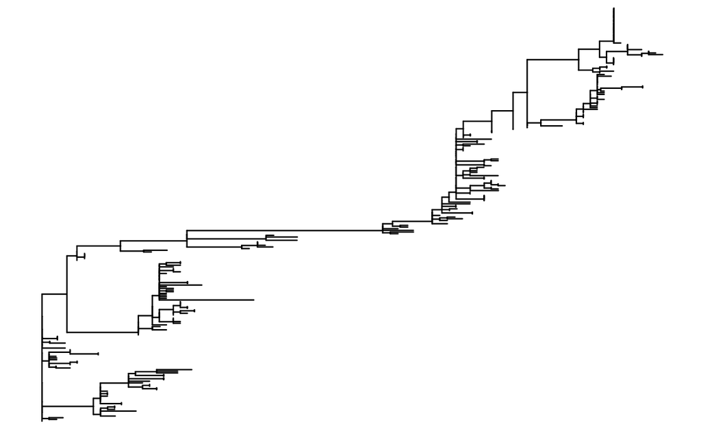

```r
file_NSnewick <- "./tree_builds/B_Vic_B_Yam_NS_Maryland_epiflu_isolates_gisaid_RAXML_ALL.newick"

#Importing newick file
NSnewick <- read.newick(file_NSnewick, node.label = "label") #import newick tree
NS_RAXML <-  ggtree(NSnewick) #generate tree
NS_RAXML #show reww without annotations
```

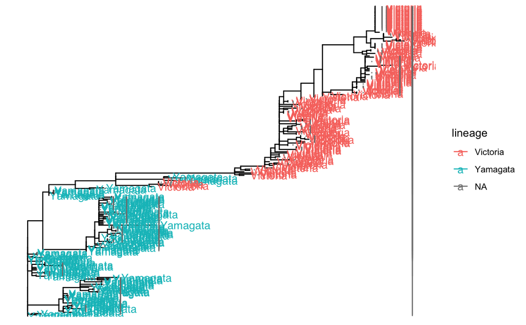

```r
##adding meta data
NS_node <- NS_RAXML %>% as.treedata %>% as_tibble() #label nodes as numbers
NS_node <- as.phylo(NS_node) #convert to phylo object
#x <- tibble(label = as.phylo(pHA_RAXML)$tip.label, trait = HA_meta) #import meta data
NS_node_join <- full_join(NS_node, NS_meta, by = "label") #merge tree and metadata
NS_node_join <- as_tibble(NS_node_join) #convert to tibble

NS_RAXML + geom_cladelab(data = NS_node_join, mapping = aes(node = node, label = lineage, color = lineage)) #plot tree with just tip colors
```

```r
#Additional Annotations with tips and node lables
NS_RAXML_meta <- ggtree(NSnewick, aes(color=NS_node_join$lineage)) +
  scale_color_manual(values=c("blue", "red"))

pNS_RAXML_meta <- NS_RAXML_meta +
  #for highlight lineages with bars..you have to select the divergent nodes which is tedious...
  #geom_treescale() +
  #Yamagata
  #geom_cladelab(node=200,
  #              label="Yamagata",
  #              barcolour='red',
  #              offset = 0,
  #              offset.text = 0.003,
  #              barsize = 1,
  #              align=TRUE,
  #              angle=270,
  #              hjust='center',
  #              fontsize = 6) +
  #Victoria
  #geom_cladelab(node=314,
  #             label="Victoria",
  #              barcolour='blue',
  #              barsize = 1,
  #              offset = 0.01495,
  #              offset.text = 0.003,
  #              align=TRUE,
  #              angle=270,
  #              hjust='center',
  #              fontsize = 6) +
  geom_tiplab(aes(subset=(grepl("B/Baltimore/R0122/2016",label,fixed=TRUE)==TRUE)), align = TRUE, offset= -0.01, size = 4 +
  geom_tiplab(aes(subset=(grepl("B/Baltimore/R0001/2016",label,fixed=TRUE)==TRUE)), align = TRUE, offset= -0.01, size = 4) +
  geom_tiplab(aes(subset=(grepl("B/Baltimore/R0250/2018",label,fixed=TRUE)==TRUE)), align = TRUE, offset= -0.01, size = 4) +
  geom_tiplab(aes(subset=(grepl("B/Baltimore/R0337/2017",label,fixed=TRUE)==TRUE)), align = TRUE, offset= -0.01, size = 4) +
  geom_tippoint(aes(color = NS_node_join$lineage), size = 0.75, alpha = 0.75) +
  scale_x_continuous(limits = c(0, 0.15)) +
  scale_y_continuous(limits = c(-8,260)) +
  theme_tree() +
  geom_treescale(x=0.01, y = -8, fontsize = 3, offset.label = 1) +
  theme(legend.position = 'none') + ggtitle("B/Victoria and B/Yamagata NS RAXML Nu Tree")

pNS_RAXML_meta
```

```
Error: unexpected symbol in:
"
pNS_RAXML_meta"
```

## NS Protein Trees - Broken down to NS1 and NS2 Trees

Adding alignment with msaplot and geom_facet with ggmsa

function (p, fasta, offset = 0, width = 1, color = NULL, window = NULL, bg_line = TRUE, height = 0.8)

TOUGH BECAUSE you have to add single quotes at the beginning and end of fasta names to match the branch names…just did it in sublime

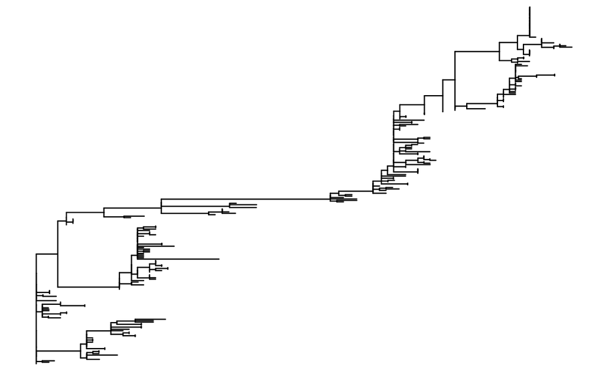

```r
file_NSnewick <- "./tree_builds/B_Vic_B_Yam_NS_Maryland_epiflu_isolates_gisaid_RAXML_ALL.newick"

#Importing newick file
NSnewick <- read.newick(file_NSnewick, node.label = "label") #import newick tree
NS_RAXML <-  ggtree(NSnewick) #generate tree
NS_RAXML #show reww without annotations
```

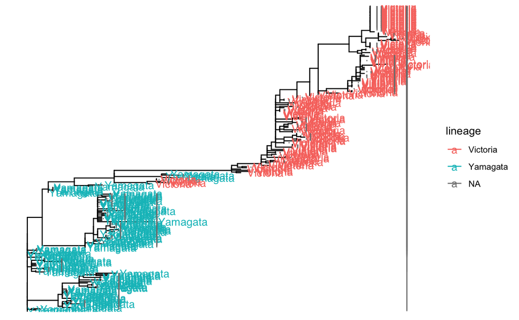

```r
##adding meta data
NS_node <- NS_RAXML %>% as.treedata %>% as_tibble() #label nodes as numbers
NS_node <- as.phylo(NS_node) #convert to phylo object
#x <- tibble(label = as.phylo(pHA_RAXML)$tip.label, trait = HA_meta) #import meta data
NS_node_join <- full_join(NS_node, NS_meta, by = "label") #merge tree and metadata
NS_node_join <- as_tibble(NS_node_join) #convert to tibble

NS_RAXML + geom_cladelab(data = NS_node_join, mapping = aes(node = node, label = lineage, color = lineage)) #plot tree with just tip colors
```

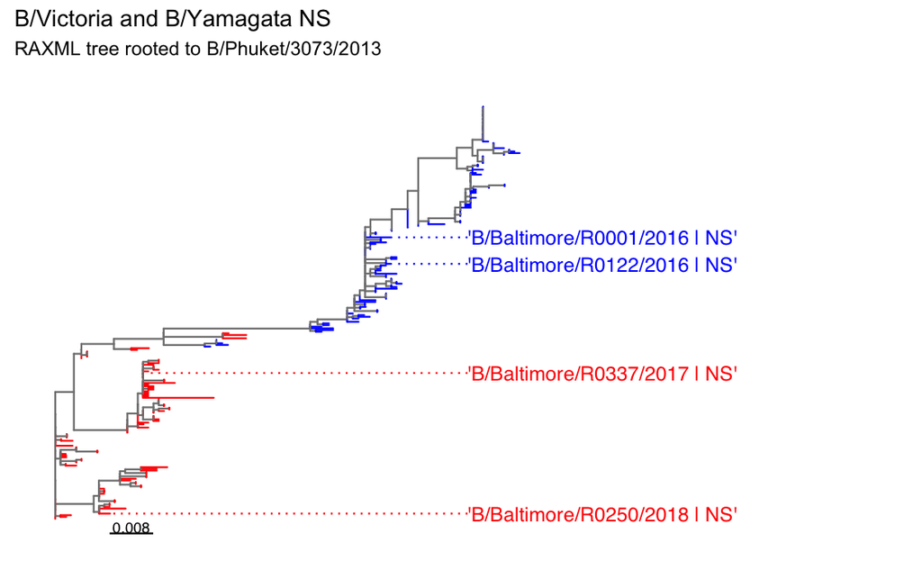

```r
#Additional Annotations with tips and node lables
NS_RAXML_meta <- ggtree(NSnewick, aes(color=NS_node_join$lineage)) +
  scale_color_manual(values=c("blue", "red"))

pNS_RAXML_meta <- NS_RAXML_meta +
  #geom_treescale() +
  #Yamagata
  #geom_cladelab(node=200,
  #              label="Yamagata",
  #              barcolour='red',
  #              offset = 0,
  #              offset.text = 0.003,
  #              barsize = 1,
  #              align=TRUE,
  #              angle=270,
  #              hjust='center',
  #              fontsize = 6) +
  #Victoria
  #geom_cladelab(node=314,
  #             label="Victoria",
  #              barcolour='blue',
  #              barsize = 1,
  #              offset = 0.01495,
  #              offset.text = 0.003,
  #              align=TRUE,
  #              angle=270,
  #              hjust='center',
  #              fontsize = 6) +
  geom_tiplab(aes(subset=(grepl("B/Baltimore/R0122/2016",label,fixed=TRUE)==TRUE)), align = TRUE, offset= -0.01, size = 4) +
  geom_tiplab(aes(subset=(grepl("B/Baltimore/R0001/2016",label,fixed=TRUE)==TRUE)), align = TRUE, offset= -0.01, size = 4) +
  geom_tiplab(aes(subset=(grepl("B/Baltimore/R0250/2018",label,fixed=TRUE)==TRUE)), align = TRUE, offset= -0.01, size = 4) +
  geom_tiplab(aes(subset=(grepl("B/Baltimore/R0337/2017",label,fixed=TRUE)==TRUE)), align = TRUE, offset= -0.01, size = 4) +
  scale_x_continuous(limits = c(0, 0.15)) +
  scale_y_continuous(limits = c(-8,260)) +
  theme_tree() +
  geom_treescale(x=0.01, y = -8, fontsize = 3, offset.label = 1) +
  theme(legend.position = 'none') + ggtitle("B/Victoria and B/Yamagata NS", "RAXML tree rooted to B/Phuket/3073/2013")
pNS_RAXML_meta

#geom_text(aes(label=node), size = 1.5 ) #labels branch node ID for labeling purposes...bc Im lazy
ggsave("./final_figs/B_Maryland_NS_tree.jpeg", plot = pNS_RAXML_meta, width = 7, height = 5) #save plot to relative dir
```

## NSp1 NSA Tree with Lineage and Sample Annotation

```r
library(ggtree)

##adding meta data
NS_node <- NS_RAXML %>% as.treedata %>% as_tibble() #label nodes as numbers
NS_node <- as.phylo(NS_node) #convert to phylo object
#x <- tibble(label = as.phylo(pHA_RAXML)$tip.label, trait = HA_meta) #import meta data
NS_node_join <- full_join(NS_node, NS_meta, by = "label") #merge tree and metadata
NS_node_join <- as_tibble(NS_node_join) #convert to tibble

NS_RAXML + geom_cladelab(data = NS_node_join, mapping = aes(node = node, label = lineage, color = lineage)) #plot tree with just tip colors

#Additional Annotations with tips and node lables
NS_RAXML_meta <- ggtree(NSnewick, aes(color=NS_node_join$lineage)) +
  scale_color_manual(values=c("blue", "red"))

NSp1_pro_file <- "./tree_builds/Maryland_Vic-Yam_NS1_msa_annotation_NSp1_pro_alignment_RAxML_Tree.newick"
NSp1_pro_msa_file <-"./tree_builds/Maryland_Vic-Yam_NS1_msa_annotation_NSp1_pro_alignment_q.fasta" #single quotes must be added to sample headers

NSp1_pro_newick <- read.newick(NSp1_pro_file , node.label = "label")
NSp1_pro_RAXML <-  ggtree(NSp1_pro_newick) +
                      theme_tree() +
                      geom_treescale(x=0.01, y = -8, fontsize = 3, offset.label = 1)#generate tree

NSp1_pro_RAXML #show without annotations


#plot msa plot
pNSp1_pro_RAXML_msa.1 <- msaplot(NSp1_pro_RAXML, fasta=NSp1_pro_msa_file, width = 6, color = ) # full msa
pNSp1_pro_RAXML_msa.2 <- msaplot(NSp1_pro_RAXML, fasta=NSp1_pro_msa_file, window = c(1,10), width = 0.5, height = 2) #msa NSp1 aa 1-10
pNSp1_pro_RAXML_msa.3 <- msaplot(NSp1_pro_RAXML, fasta=NSp1_pro_msa_file, window = c(107,127), width = 2, height = 2) #msa NSp1 aa 107-127
pNSp1_pro_RAXML_msa.4 <- msaplot(NSp1_pro_RAXML, fasta=NSp1_pro_msa_file, window = c(130,140), width = 2, height = 2) #msa NSp1 aa 107-127
pNSp1_pro_RAXML_msa.5 <- msaplot(NSp1_pro_RAXML, fasta=NSp1_pro_msa_file, window = c(1,10), width = 0.5, height = 2) + coord_polar(theta='y') #circular plot

#show plots
pNSp1_pro_RAXML_msa.1 + ggtitle("NS1 Protein Tree", subtitle = "With Complete Alignment rooted to B/Phuket/3073/2013")

pNSp1_pro_RAXML_msa.2 + ggtitle("NS1 Protein Tree", subtitle = "Residues: 1-10 rooted to B/Phuket/3073/2013")

pNSp1_pro_RAXML_msa.3 + ggtitle("NS1 Protein Tree", subtitle = "Residues: 107-127 rooted to B/Phuket/3073/2013")

pNSp1_pro_RAXML_msa.4 + ggtitle("NS1 Protein Tree", subtitle = "Residues: 130-140 rooted to B/Phuket/3073/2013")

pNSp1_pro_RAXML_msa.5 + ggtitle("NS1 Protein Tree", subtitle = "Residues: 1-10 circular rooted to B/Phuket/3073/2013")

pNSp1_pro_RAXML_msa.2 + pNSp1_pro_RAXML_msa.5

#ggsave("B_Maryland_NSp1-pro_tree_130-140_FINAL.jpeg", width = 11, height = 5) #saves pNSp1_pro_RAXML_msa.3
```

ggtree MSA facet from: (link)[https://github.com/YuLab-SMU/ggmsa/issues/7]

```r
library(ggmsa)
library(Biostrings)
library(ape)
library(ggtree)

NSp1_pro_msa_file <-"./tree_builds/Maryland_Vic-Yam_NS1_msa_annotation_NSp1_pro_alignment_q.fasta"

NSp1_pro_seq <- readAAStringSet(NSp1_pro_msa_file)
NSp1_pro_seq

NSp1_window.1 = tidy_msa(NSp1_pro_seq, 1,20)
NSp1_window.2 = tidy_msa(NSp1_pro_seq, 107,127)
NSp1_window.3 = tidy_msa(NSp1_pro_seq, 130,140)


NSp1_pro_RAXML +
  geom_facet(geom = geom_msa, data = NSp1_window.1, panel = 'msa', font = NULL, color = "Chemistry_AA") +
  geom_facet(geom = ggmsa:::geom_logo, data = data, panel='msa', color = "Chemistry_AA", adaptive = T, height = 1)


NSp1_pro_RAXML +
  geom_facet(geom = geom_msa, data = NSp1_window.2, panel = 'msa', font = NULL, color = "Chemistry_AA") +
  geom_facet(geom = ggmsa:::geom_logo, data = data, panel='msa', color = "Chemistry_AA", adaptive = T, height = 1)


NSp1_pro_RAXML +
  geom_facet(geom = geom_msa, data = NSp1_window.3, panel = 'msa', font = NULL, color = "Chemistry_AA") +
  geom_facet(geom = ggmsa:::geom_logo, data = data, panel='msa', color = "Chemistry_AA", adaptive = T, height = 1)
```

## NSP2 Tree

STUPID quotes I hate it here…

```r
library(ggtree)

NSp2_pro_file <- "./tree_builds/Maryland_Vic-Yam_NS1_msa_annotation_NSp2_pro_alignment_RAxML_Tree.newick"
NSp2_pro_msa_file <-"./tree_builds/Maryland_Vic-Yam_NS1_msa_annotation_NSp2_pro_alignment_q.fasta" #single quotes must be added to sample headers

NSp2_pro_newick <- read.newick(NSp2_pro_file , node.label = "label")
NSp2_pro_RAXML <-  ggtree(NSp2_pro_newick) +
                      theme_tree() +
                      geom_treescale(x=0.01, y = -8, fontsize = 3, offset.label = 1)#generate tree

NSp2_pro_RAXML #show reww without annotations

#plot msa plot
pNSp2_pro_RAXML_msa.1 <- msaplot(NSp2_pro_RAXML, fasta=NSp2_pro_msa_file, width = 7, height = 2 ) # full msa
pNSp2_pro_RAXML_msa.2 <- msaplot(NSp2_pro_RAXML, fasta=NSp2_pro_msa_file, window = c(1,10), width = 0.5, height = 2 ) #msa NSp1 aa 1-10
pNSp2_pro_RAXML_msa.3 <- msaplot(NSp2_pro_RAXML, fasta=NSp2_pro_msa_file, window = c(20, 30), width = 2, height = 2) #msa NSp1 aa 1-50

#show plots
pNSp2_pro_RAXML_msa.1 + ggtitle("NS2 Protein Tree", subtitle = "With Complete Alignment rooted to B/Phuket/3073/2013")
pNSp2_pro_RAXML_msa.2 + ggtitle("NS2 Protein Tree", subtitle = "Residues: 1-10 rooted to B/Phuket/3073/2013")
pNSp2_pro_RAXML_msa.3 + ggtitle("NS2 Protein Tree", subtitle = "Residues: 20-30 rooted to B/Phuket/3073/2013")


#ggsave("B_Maryland_NSp1-pro_tree_130-140_FINAL.jpeg", width = 11, height = 5) #saves pNSp1_pro_RAXML_msa.3
```